# Week 6 Day 2 Homework

```r
library(stats)
library(janitor)
library(here)
library(tidyverse)
here::here()
```

```
[1] "C:/Users/colin/Documents/CodeClan/codeclan_homework_ColinS/week_06/day_2"
```

# Question 1.

Load the data, `clean_names()` and explore it.

```r
phones <- read_csv(here("data/20190928-items.csv")) %>% clean_names()
```

```r
dim(phones)
```

```
[1] 792   9
```

The dataset contains 792 observations of 9 variables.

```r
str(phones)
```

```
spec_tbl_df [792 x 9] (S3: spec_tbl_df/tbl_df/tbl/data.frame)
 $ asin         : chr [1:792] "B0000SX2UC" "B0009N5L7K" "B000SKTZ0S" "B00198M12M" ...
 $ brand        : chr [1:792] "Nokia" "Motorola" "Motorola" "Nokia" ...
 $ title        : chr [1:792] "Dual-Band / Tri-Mode Sprint PCS Phone w/ Voice Activated Dialing & Bright White Backlit Screen" "Motorola I265 phone" "MOTOROLA C168i AT&T CINGULAR PREPAID GOPHONE CELL PHONE" "Nokia 6500 Slide Black/silver Unlocked Cell Phone" ...
 $ url          : chr [1:792] "https://www.amazon.com/Dual-Band-Tri-Mode-Activated-Dialing-Backlit/dp/B0000SX2UC" "https://www.amazon.com/Motorola-i265-I265-phone/dp/B0009N5L7K" "https://www.amazon.com/MOTOROLA-C168i-CINGULAR-PREPAID-GOPHONE/dp/B000SKTZ0S" "https://www.amazon.com/Nokia-6500-Slide-si…
 $ image        : chr [1:792] "https://m.media-amazon.com/images/I/2143EBQ210L._AC_UY218_SEARCH213888_FMwebp_QL75_.jpg" "https://m.media-amazon.com/images/I/419WBAVDARL._AC_UY218_SEARCH213888_FMwebp_QL75_.jpg" "https://m.media-amazon.com/images/I/71b+q3ydkIS._AC_UY218_SEARCH213888_FMwebp_QL75_.jpg" …
 $ rating       : num [1:792] 3 2.9 2.6 2.4 3.3 3.2 2 2.7 3.2 3.5 ...
 $ review_url   : chr [1:792] "https://www.amazon.com/product-reviews/B0000SX2UC" "https://www.amazon.com/product-reviews/B0009N5L7K" "https://www.amazon.com/product-reviews/B000SKTZ0S" "https://www.amazon.com/product-reviews/B00198M12M" ...
 $ total_reviews: num [1:792] 14 7 22 5 21 12 1 3 8 133 ...
 $ prices       : chr [1:792] NA "$49.95" NA NA ...
 - attr(*, "spec")=
  .. cols(
  ..   asin = col_character(),
  ..   brand = col_character(),
  ..   title = col_character(),
  ..   url = col_character(),
  ..   image = col_character(),
  ..   rating = col_double(),
  ..   reviewUrl = col_character(),
  ..   totalReviews = col_double(),
  ..   prices = col_character()
  .. )
 - attr(*, "problems")=<externalptr>
```

```r
head(phones)
```

| asin | brand | title | url | image | rating | review_url | total_reviews | prices |
| --- | --- | --- | --- | --- | --- | --- | --- | --- |
| B0000SX2UC | Nokia | Dual-Band / Tri-Mode Sprint PCS Phone w/ Voice Activated Dialing & Bright White Backlit Screen | https://www.amazon.com/Dual-Band-Tri-Mode-Activated-Dialing-Backlit/dp/B0000SX2UC | https://m.media-amazon.com/images/I/2143EBQ210L._AC_UY218_SEARCH213888_FMwebp_QL75_.jpg | 3.0 | https://www.amazon.com/product-reviews/B0000SX2UC | 14 | NA |
| B0009N5L7K | Motorola | Motorola I265 phone | https://www.amazon.com/Motorola-i265-I265-phone/dp/B0009N5L7K | https://m.media-amazon.com/images/I/419WBAVDARL._AC_UY218_SEARCH213888_FMwebp_QL75_.jpg | 2.9 | https://www.amazon.com/product-reviews/B0009N5L7K | 7 | $49.95 |
| B000SKTZ0S | Motorola | MOTOROLA C168i AT&T CINGULAR PREPAID GOPHONE CELL PHONE | https://www.amazon.com/MOTOROLA-C168i-CINGULAR-PREPAID-GOPHONE/dp/B000SKTZ0S | https://m.media-amazon.com/images/I/71b+q3ydkIS._AC_UY218_SEARCH213888_FMwebp_QL75_.jpg | 2.6 | https://www.amazon.com/product-reviews/B000SKTZ0S | 22 | NA |
| B00198M12M | Nokia | Nokia 6500 Slide Black/silver Unlocked Cell Phone | https://www.amazon.com/Nokia-6500-Slide-silver-Unlocked/dp/B00198M12M | https://m.media-amazon.com/images/I/41ss4HpLkLL._AC_UY218_SEARCH213888_FMwebp_QL75_.jpg | 2.4 | https://www.amazon.com/product-reviews/B00198M12M | 5 | NA |
| B001AO4OUC | Motorola | Motorola i335 Cell Phone Boost Mobile | https://www.amazon.com/Motorola-i335-Phone-Boost-Mobile/dp/B001AO4OUC | https://m.media-amazon.com/images/I/710UO8gdT+L._AC_UY218_SEARCH213888_FMwebp_QL75_.jpg | 3.3 | https://www.amazon.com/product-reviews/B001AO4OUC | 21 | NA |
| B001DCJAJG | Motorola | Motorola V365 no contract cellular phone AT&T | https://www.amazon.com/Motorola-V365-contract-cellular-phone/dp/B001DCJAJG | https://m.media-amazon.com/images/I/61LYNCVrrKL._AC_UY218_SEARCH213888_FMwebp_QL75_.jpg | 3.2 | https://www.amazon.com/product-reviews/B001DCJAJG | 12 | NA |

# Question 2.

Find the brand with the highest numbers of phones in the dataset.

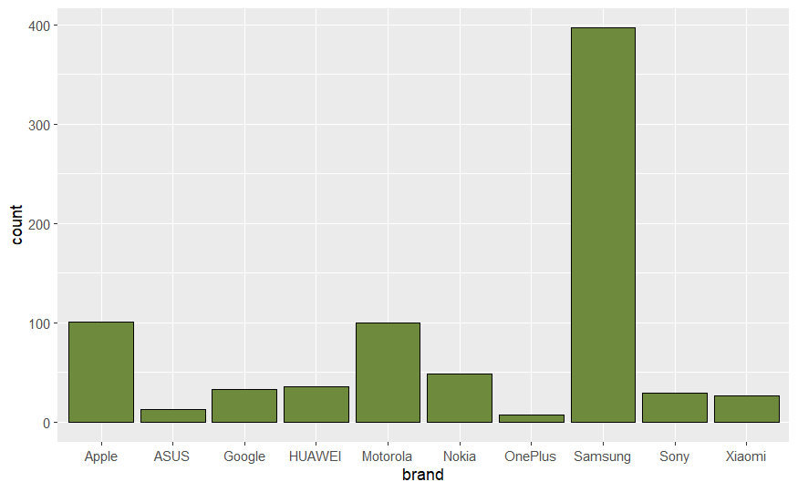

```r
phones %>%

  ggplot() +
  aes(x = brand) %>%
  geom_bar(colour = "black", fill = "darkolivegreen4")
```

```r
NA
```

**Samsung have the highest number of phones in the data set.**

# Question 3.

For your top brand, plot the distribution of phone ratings as a probability density, overlaying a fitted normal distribution. Do you think the normal distribution provides a good model of these ratings?

```r
samsung <- phones %>%
  filter(brand == "Samsung")
samsung
```

| asin | brand | title | url | image | rating | review_url | total_reviews | prices |
| --- | --- | --- | --- | --- | --- | --- | --- | --- |
| B00280QJFU | Samsung | Samsung T301G Prepaid Phone (Tracfone) | https://www.amazon.com/Samsung-T301G-Prepaid-Phone-Tracfone/dp/B00280QJFU | https://m.media-amazon.com/images/I/71QX+Kiri4L._AC_UY218_SEARCH213888_FMwebp_QL75_.jpg | 3.5 | https://www.amazon.com/product-reviews/B00280QJFU | 133 | $59.89 |
| B002AS9WEA | Samsung | Samsung a167 Prepaid GoPhone (AT&T) | https://www.amazon.com/Samsung-a167-Prepaid-GoPhone-AT/dp/B002AS9WEA | https://m.media-amazon.com/images/I/61OXcZ-oefL._AC_UY218_SEARCH213888_FMwebp_QL75_.jpg | 2.9 | https://www.amazon.com/product-reviews/B002AS9WEA | 18 | $149.95 |
| B003FCO9XE | Samsung | Samsung Smooth Verizon Wireless Prepaid Mobile Cell Camera Phone CDMA | https://www.amazon.com/Samsung-Smooth-Verizon-Wireless-Prepaid/dp/B003FCO9XE | https://m.media-amazon.com/images/I/61nD-TYqHmL._AC_UY218_SEARCH213888_FMwebp_QL75_.jpg | 2.8 | https://www.amazon.com/product-reviews/B003FCO9XE | 76 | NA |
| B003MW0OIQ | Samsung | Samsung a107 Prepaid GoPhone (AT&T) | https://www.amazon.com/Samsung-a107-Prepaid-GoPhone-AT/dp/B003MW0OIQ | https://m.media-amazon.com/images/I/71QGO7a7YNL._AC_UY218_SEARCH213888_FMwebp_QL75_.jpg | 2.6 | https://www.amazon.com/product-reviews/B003MW0OIQ | 131 | NA |
| B003P2VNAQ | Samsung | Samsung Rugby II, Black (AT&T) | https://www.amazon.com/Samsung-Rugby-II-Black-AT/dp/B003P2VNAQ | https://m.media-amazon.com/images/I/81RAS6NJR5L._AC_UY218_SEARCH213888_FMwebp_QL75_.jpg | 3.2 | https://www.amazon.com/product-reviews/B003P2VNAQ | 66 | NA |
| B003XREZ4O | Samsung | Samsung Gusto, Black (Verizon Wireless) | https://www.amazon.com/Samsung-Gusto-Black-Verizon-Wireless/dp/B003XREZ4O | https://m.media-amazon.com/images/I/8119wz+eORL._AC_UY218_SEARCH213888_FMwebp_QL75_.jpg | 2.0 | https://www.amazon.com/product-reviews/B003XREZ4O | 15 | NA |
| B004C7NVD0 | Samsung | Samsung Convoy SCH-U640 Cell Phone Ruggedized PTT 2+ megapixel Camera for Verizon | https://www.amazon.com/Samsung-SCH-U640-Ruggedized-megapixel-Verizon/dp/B004C7NVD0 | https://m.media-amazon.com/images/I/61ve0RjDSUL._AC_UY218_SEARCH213888_FMwebp_QL75_.jpg | 3.4 | https://www.amazon.com/product-reviews/B004C7NVD0 | 102 | NA |
| B004GLQTG8 | Samsung | Samsung R355C Net 10 Unlimited | https://www.amazon.com/Samsung-R355C-Net-10-Unlimited/dp/B004GLQTG8 | https://m.media-amazon.com/images/I/51p8LMQ-rIL._AC_UY218_SEARCH213888_FMwebp_QL75_.jpg | 3.5 | https://www.amazon.com/product-reviews/B004GLQTG8 | 146 | $79.99 |
| B004H23JXW | Samsung | Samsung Focus I917 Unlocked Phone with Windows 7 OS, 5 MP Camera, and Wi-Fi--No Warranty (Black) | https://www.amazon.com/Samsung-I917-Unlocked-Wi-Fi-No-Warranty/dp/B004H23JXW | https://m.media-amazon.com/images/I/81v2NUARf6L._AC_UY218_SEARCH213888_FMwebp_QL75_.jpg | 3.4 | https://www.amazon.com/product-reviews/B004H23JXW | 348 | NA |
| B004UVR9A4 | Samsung | Samsung Factor Prepaid Phone (Boost Mobile) | https://www.amazon.com/Samsung-Factor-Prepaid-Phone-Mobile/dp/B004UVR9A4 | https://m.media-amazon.com/images/I/81AkHig97BL._AC_UY218_SEARCH213888_FMwebp_QL75_.jpg | 3.4 | https://www.amazon.com/product-reviews/B004UVR9A4 | 56 | NA |

[output cut: 387 more lines]

The mean rating is 3.5733 and the standard deviation in rating is 0.6847859;

```r
samsung_stats <- samsung %>%
  summarise(num = n(),
            mean_rating = mean(rating),
            sd_rating = sd(rating))

samsung_stats
```

| num | mean_rating | sd_rating |
| --- | --- | --- |
| 397 | 3.5733 | 0.6847859 |

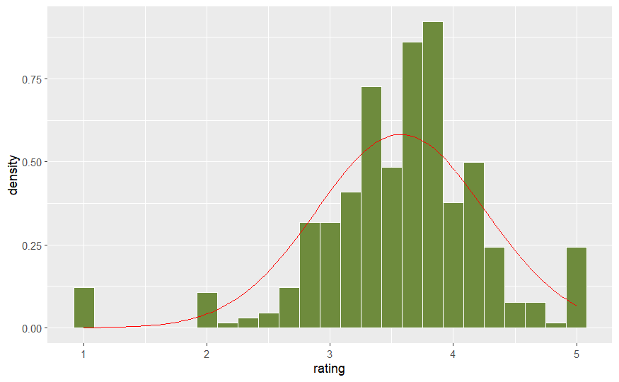

```r
samsung %>%
  ggplot() +
  aes(x = rating) +
  geom_histogram(aes(y = ..density..),
                 col = "white",
                 fill = "darkolivegreen4",
                 bins = 25) +
  stat_function(fun = dnorm,
                args = list(mean = samsung_stats$mean_rating,
                            sd = samsung_stats$sd_rating),
                colour = "red")
```

```r
NA
NA
NA
```

**On the appearance of th graph alone, the data appears to be a reasonable fit to** **the normal distribution.**

# Question 4.

We can be more quantitative in comparing the distribution of top brand ratings with a normal distribution. You calculated the mean() and sd() of your distribution in an earlier question. Use these values to calculate the proportions of ratings within one-, two- and three standard deviations of the mean. Compare these proportions with those you expect for a normal distribution.

```r
samsung %>%
  dplyr::filter(rating >= samsung_stats$mean_rating - samsung_stats$sd_rating) %>%
  dplyr::filter(rating <= samsung_stats$mean_rating + samsung_stats$sd_rating) %>%
  summarise(prop_within_1sd = n() / nrow(samsung))
```

| prop_within_1sd |
| --- |
| 0.7934509 |

**The proportion of data within 1 standard deviation is 0.793.**

```r
# 2 SD
samsung %>%
  dplyr::filter(rating >= samsung_stats$mean_rating - 2*(samsung_stats$sd_rating)) %>%
  dplyr::filter(rating <= samsung_stats$mean_rating + 2*(samsung_stats$sd_rating)) %>%
  summarise(prop_within_2sd = n() / nrow(samsung))
```

| prop_within_2sd |
| --- |
| 0.9193955 |

**The proportion of data within 2 standard deviations is 0.919.**

```r
# 3 SD
samsung %>%
  dplyr::filter(rating >= samsung_stats$mean_rating - 3*(samsung_stats$sd_rating)) %>%
  dplyr::filter(rating <= samsung_stats$mean_rating + 3*(samsung_stats$sd_rating)) %>%
  summarise(prop_within_3sd = n() / nrow(samsung))
```

| prop_within_3sd |
| --- |
| 0.9798489 |

**The proportion of data within 3 standard deviations is 0.980.**

The “textbook” normal distribution has standard deviation boudaries as follows;

```r
100 * (pnorm(q = 1) - pnorm(q = -1)) # 1 SD
```

```
[1] 68.26895
```

```r
100 * (pnorm(q = 2) - pnorm(q = -2)) # 2 SD
```

```
[1] 95.44997
```

```r
100 * (pnorm(q = 3) - pnorm(q = -3)) # 3 SD
```

```
[1] 99.73002
```

So to summarise;

| SD | Normal Dist. | Samsung Dist. |
| --- | --- | --- |
| 1 | 0.683 | 0.793 |
| 2 | 0.954 | 0.919 |
| 3 | 0.997 | 0.980 |